# MYCN-NBL Subtyping

Aditya Lahiri, Eric Wafula, Jo Lynne Rokita

10/13/2022

# Objective:

To molecularly subtype neuroblastoma, ganglioneuroblastoma, and ganglioneuroma samples into MYCN amplified or MYCN non-amplified.

#Load Libraries

```r
library(dplyr)
library(data.table)
library(tidyverse)
library(ggplot2)
```

#Set up directories

```r
# root directory
root_dir <- rprojroot::find_root(rprojroot::has_dir(".git"))

# data directory
dataDir <- file.path(root_dir, "data")

# module directory
moduleDir <- file.path(root_dir, "analyses","molecular-subtyping-NBL")

#results directory
results_dir <- "results"
# create if doesn't exist
if (!dir.exists(results_dir)) {
  dir.create(results_dir)
}

#util directory
util_dir <- "util"
if (!dir.exists(util_dir)) {
  dir.create(util_dir)
}

#intermediate directory
intermediate_dir <- "intermediate"
if (!dir.exists(intermediate_dir)) {
  dir.create(intermediate_dir)
}

#plot directory
plot_dir <- "plots"
# create if doesn't exist
if (!dir.exists(plot_dir)) {
  dir.create(plot_dir)
}
```

#Load all the datafiles in the ticket and plot function

```r
hist_df<-readr::read_tsv(file.path(dataDir, "histologies-base.tsv"),guess_max = 100000)
consensus_df<-readr::read_tsv(file.path(dataDir, "consensus_wgs_plus_cnvkit_wxs.tsv.gz"),guess_max = 100000)
cnv_cnvkit_df<-readr::read_tsv(file.path(dataDir, "cnv-cnvkit.seg.gz"),guess_max = 100000)
cnv_controlfreec_df<-readr::read_tsv(file.path(dataDir, "cnv-controlfreec.tsv.gz"),guess_max = 100000)
gene_expression_df<-as.data.frame(readRDS(paste(dataDir,"/","gene-expression-rsem-tpm-collapsed.rds",sep="")))
gmkf_patient_clinical_mycn_status_df <- readr::read_tsv(file.path(moduleDir, "input/gmkf_patient_clinical_mycn_status.tsv"),guess_max = 100000)
target_patient_clinical_mycn_status_df<- readr::read_tsv(file.path(moduleDir, "input/target_patient_clinical_mycn_status.tsv"),guess_max = 100000)
```

# source function to plot of the chromosome 2 segment mean for a particular biospecimen

```r
source(file.path(moduleDir,"util", "plot_chr2.R"))
```

Background: NBL is defined as neuroblastoma, ganglioneuroblastoma, and ganglioneuroma.These diseases are mentioned in the histology-base.tsv file. consensus_wgs_plus_cnvkit_wxs.tsv.gz has information regarding copy number, status, and gene symbol (MYCN). gene-expression-rsem-tpm-collapsed.rds file has MYCN TPM values.

Code Logic: We first filter the histology-base.tsv file for NBL samples based on pathology_diagnosis, sample_type, and experimental strategy. The pathology_diagnosis can have certain values as listed in the code chunk below. The sample type we query for is “tumor”, i.e. we exclude “normal” samples. For experimental strategy, we consider WGS, WXS, Targeted Sequencing, and RNA-Seq. We ultimately want to create an output table with DNA and RNA biospecimen IDs, with their corresponding molecular subtype, so we will need get DNA and RNA samples from the histology file.

We filter the consensus_wgs_plus_cnvkit_wxs.tsv.gz and gene-expression-rsem-tpm-collapsed.rds for MYCN to get the relevant information. # Data Filtering

```r
# First filter the histology file based on diseases we are intereseted in neuroblastoma, ganglioneuroblastoma, and ganglioneuroma
hist_filtered_df <- hist_df %>%
  filter(sample_type=="Tumor",
         experimental_strategy %in% c("WGS", "WXS", "Targeted Sequencing", "RNA-Seq")) %>%
  filter(pathology_diagnosis== "Neuroblastoma" |
           pathology_diagnosis== "Ganglioneuroblastoma" |
           pathology_diagnosis== "Ganglioneuroblastoma, nodular" |
           pathology_diagnosis == "Ganglioneuroblastoma, intermixed" |
           pathology_diagnosis == "Ganglioneuroma, maturing subtype OR Ganglioneuroblastoma, well differentiated")


# The consensus_wgs_plus_cnvkit_wxs.tsv.gz file has all types of genes, we just need MYCN, so we filter the dataset as follows:
consensus_filtered_df <- consensus_df %>% filter(gene_symbol=="MYCN")

# Get MYCN TPM Data
MYCN_Index <- which(rownames(gene_expression_df)=="MYCN") # find which rows (contains gene names) corresponds to MYCN
TPM_MYCN_data <- gene_expression_df[MYCN_Index,] # Get the TPM data for for MYCN
```

Code Logic: We will integrate the TMP and cnv data with the hist_filtered using left join. Histology file has all the IDs but we are only concerned with NBL-MYCN IDs, so we use the filtered version of histology file.

# Get TPM , Copy Number and Status

```r
#Add the satus and copy Number to these samples. Adding the information if available, so we do a left join with
#respect to hist_filtered_df as we don't want to discard any biospecimen of MYCN-NBL for which Status and copy number is not avaialable
MYCN_DF<-left_join(hist_filtered_df,consensus_filtered_df,by= c("Kids_First_Biospecimen_ID" = "biospecimen_id"))

#Add TPM in  a similar fashion as copy number and status
rownames(TPM_MYCN_data)<-"MYCN_TPM" # Defining the column names of tpm values
TPM_MYCN_data<-t(TPM_MYCN_data) # coverting 1 X N matrix to N X 1 matrix (lenght wise)
TPM_MYCN_data <-as.data.frame(TPM_MYCN_data) # Convert to data framte
TPM_MYCN_data <- tibble::rownames_to_column(TPM_MYCN_data, "Kids_First_Biospecimen_ID") # Make ID rownames into a column
# Finally add the TPM data using left join
MYCN_DF<- left_join(MYCN_DF,TPM_MYCN_data, by="Kids_First_Biospecimen_ID")
```

Code logic: MYCN_DF has 1508 records, some of the IDs in Kids_First_Biospecimen_ID are DNA IDs while others are RNA IDs. Among the DNA IDs, some have corresponding RNA IDs, so we need to first find the matching DNA/RNA IDs. To find matching RNA IDs for DNA IDs, we create a match ID by combining Kids_First_Participant_ID + Sample_ID + Cohort. To this end, we create a new column in MYCN_Df called match_id.

# Create dataframes of samples where DNA and RNA IDs match

```r
# Create Match_ID Kids_First_Participant_ID + Sample_ID + Cohort
MYCN_DF <- MYCN_DF %>%mutate(match_id = paste(Kids_First_Participant_ID, sample_id,cohort,sep = "_"))

# DNA samples are those belonging to WGS, WXS, and Targeted Sequencing experimental_strategy experimental_strategy
# However, some targeted sequencing also have RNA_Library as "exome capture" those biospecimens are RNAs.

MYCN_dna_df<-MYCN_DF %>% filter(is.na(RNA_library),experimental_strategy %in% c("WGS", "WXS", "Targeted Sequencing")) # 1103 samples samples


MYCN_rna_df<-MYCN_DF %>% filter( (experimental_strategy=="RNA-Seq") | (experimental_strategy=="Targeted Sequencing" & !is.na(RNA_library)))
# 405 samples 374 rna-seq + 31 targeted_seq+exome_capture

# Rename the columns
colnames(MYCN_dna_df)[which(names(MYCN_dna_df) == "Kids_First_Biospecimen_ID")] <- "Kids_First_Biospecimen_ID_DNA"
colnames(MYCN_rna_df)[which(names(MYCN_rna_df) == "Kids_First_Biospecimen_ID")] <- "Kids_First_Biospecimen_ID_RNA"
```

Code Logic: Now find the intersection of MYCN_dna_df and MYCN_rna_df, this will give us a dataframe of matching DNA and RNA biospecimen IDs. We then select specific columns from the joined dataframe for downstream analysis.

```r
MYCN_DNA_RNA_DF <- inner_join(MYCN_dna_df,MYCN_rna_df, by="match_id")  # 342 samples

# Retain the information of RNA/DNA Biospecimen ID, gene symbol, cancer group, pathology free text diagnosis, copy number, TPM and status
MYCN_DNA_RNA_FILTERED_DF <- MYCN_DNA_RNA_DF %>% select(Kids_First_Biospecimen_ID_DNA,Kids_First_Biospecimen_ID_RNA,
                                                       Kids_First_Participant_ID.x,Kids_First_Participant_ID.y,
                                              gene_symbol.x,gene_symbol.y,
                                              pathology_diagnosis.x,pathology_diagnosis.y,
                                              pathology_free_text_diagnosis.x,pathology_free_text_diagnosis.y,
                                              copy_number.x,copy_number.y,MYCN_TPM.x,MYCN_TPM.y,status.x,status.y, match_id)
# Remove columns with no info, the following code logic is adapted from [2]
empty_columns <- colSums(is.na(MYCN_DNA_RNA_FILTERED_DF) | MYCN_DNA_RNA_FILTERED_DF == "") == nrow(MYCN_DNA_RNA_FILTERED_DF)

#Remove empty coulmns
MYCN_DNA_RNA_FILTERED_DF<- MYCN_DNA_RNA_FILTERED_DF[!empty_columns]

#Check if the copies of pathology_diagnosis, pathology_free_text_diagnosism status are identitical. These copies
# are created due to inner join of MYCN_dna_df and MYCN_rna_df
print(all.equal(MYCN_DNA_RNA_FILTERED_DF$pathology_diagnosis.x,MYCN_DNA_RNA_FILTERED_DF$pathology_diagnosis.y))
```

```
[1] TRUE
```

```r
print(all.equal(MYCN_DNA_RNA_FILTERED_DF$pathology_free_text_diagnosis.x,MYCN_DNA_RNA_FILTERED_DF$pathology_free_text_diagnosis.y))
```

```
[1] TRUE
```

```r
print(all.equal(MYCN_DNA_RNA_FILTERED_DF$Kids_First_Participant_ID.x,MYCN_DNA_RNA_FILTERED_DF$Kids_First_Participant_ID.y))
```

```
[1] TRUE
```

```r
# since they are identical we can remove the duplicated columns.

# Remove duplicate columns after inspection
duplicate_columns <- c("pathology_diagnosis.y","pathology_free_text_diagnosis.y","Kids_First_Participant_ID.y")
MYCN_DNA_RNA_FILTERED_DF<-MYCN_DNA_RNA_FILTERED_DF[ , -which(names(MYCN_DNA_RNA_FILTERED_DF) %in% duplicate_columns)] # 342 samples


# Rename the columns appropriately.
colnames(MYCN_DNA_RNA_FILTERED_DF)<-c("Kids_First_Biospecimen_ID_DNA","Kids_First_Biospecimen_ID_RNA",
                                      "Kids_First_Participant_ID","gene_symbol","cancer_group",
                                      "pathology_free_text_diagnosis","copy_number","MYCN_TPM","status","Match_ID")
```

Code Logic: In MYCN_DNA_RNA_FILTERED_DF we want to find the repeating Kids_First_Biospecimen_ID_DNA We do not need to check for repeating Kids_First_Biospecimen_ID_RNA as all the DNA and RNA IDs are matched in MYCN_DNA_RNA_FILTERED_DF. Therefore if we find a repeating DNA ID, we will also find its corresponding RNA ID which will also be repeating.

```r
# We will check only repeating DNA IDs as the records unique in MYCN_DNA_RNA_FILTERED_DF when we query them with
# DNA IDs + RNA IDs.
MYCN_Table <- as.data.frame(table(MYCN_DNA_RNA_FILTERED_DF$Kids_First_Biospecimen_ID_DNA))
colnames(MYCN_Table)<- c("Kids_First_Biospecimen_ID_DNA", "Freq")
MYCN_Table$Kids_First_Biospecimen_ID_DNA<-as.character(MYCN_Table$Kids_First_Biospecimen_ID_DNA)
index_repeats <- which(MYCN_Table$Freq>1)
repeated_ids <- MYCN_Table$Kids_First_Biospecimen_ID_DNA[index_repeats]
for (iter in 1:length(repeated_ids))
  print(MYCN_DNA_RNA_FILTERED_DF[MYCN_DNA_RNA_FILTERED_DF$Kids_First_Biospecimen_ID_DNA==repeated_ids[iter],])
```

| Kids_First_Biospecimen_ID_DNA | Kids_First_Biospecimen_ID_RNA | Kids_First_Participant_ID | gene_symbol | cancer_group | pathology_free_text_diagnosis | copy_number | MYCN_TPM | status | Match_ID |
| --- | --- | --- | --- | --- | --- | --- | --- | --- | --- |
| BS_0XC02E11 | BS_2HM4AE24 | PT_V5PCYAFJ | NA | Neuroblastoma | NA | NA | NA | NA | PT_V5PCYAFJ_ET_FD9T78QE_DGD |
| BS_0XC02E11 | BS_XV40PE3Q | PT_V5PCYAFJ | NA | Neuroblastoma | NA | NA | NA | NA | PT_V5PCYAFJ_ET_FD9T78QE_DGD |

| Kids_First_Biospecimen_ID_DNA | Kids_First_Biospecimen_ID_RNA | Kids_First_Participant_ID | gene_symbol | cancer_group | pathology_free_text_diagnosis | copy_number | MYCN_TPM | status | Match_ID |
| --- | --- | --- | --- | --- | --- | --- | --- | --- | --- |
| BS_1F8J25Q1 | BS_2HM4AE24 | PT_V5PCYAFJ | NA | Neuroblastoma | NA | NA | NA | NA | PT_V5PCYAFJ_ET_FD9T78QE_DGD |
| BS_1F8J25Q1 | BS_XV40PE3Q | PT_V5PCYAFJ | NA | Neuroblastoma | NA | NA | NA | NA | PT_V5PCYAFJ_ET_FD9T78QE_DGD |

| Kids_First_Biospecimen_ID_DNA | Kids_First_Biospecimen_ID_RNA | Kids_First_Participant_ID | gene_symbol | cancer_group | pathology_free_text_diagnosis | copy_number | MYCN_TPM | status | Match_ID |
| --- | --- | --- | --- | --- | --- | --- | --- | --- | --- |
| TARGET-30-PAPVFD-01A-01D | TARGET-30-PAPVFD-01A-01R | PAPVFD | MYCN | Neuroblastoma | MYCN non-amp | 2 | 83.89 | loss | PAPVFD_01_TARGET |
| TARGET-30-PAPVFD-01A-01D | TARGET-30-PAPVFD-01A-01R | PAPVFD | MYCN | Neuroblastoma | MYCN non-amp | 3 | 83.89 | neutral | PAPVFD_01_TARGET |

| Kids_First_Biospecimen_ID_DNA | Kids_First_Biospecimen_ID_RNA | Kids_First_Participant_ID | gene_symbol | cancer_group | pathology_free_text_diagnosis | copy_number | MYCN_TPM | status | Match_ID |
| --- | --- | --- | --- | --- | --- | --- | --- | --- | --- |
| TARGET-30-PASXRG-01A-01D | TARGET-30-PASXRG-01A-01R | PASXRG | MYCN | Ganglioneuroblastoma, nodular | MYCN amp | 14 | 306.49 | amplification | PASXRG_01_TARGET |
| TARGET-30-PASXRG-01A-01D | TARGET-30-PASXRG-01A-01R | PASXRG | MYCN | Ganglioneuroblastoma, nodular | MYCN amp | 4 | 306.49 | gain | PASXRG_01_TARGET |

```r
# For records BS_0XC02E11 and BS_1F8J25Q1 two samples are there, differing in aliquot_id.y
rows_to_delete_MYCN <- c(which(MYCN_DNA_RNA_FILTERED_DF$Kids_First_Biospecimen_ID_DNA=="TARGET-30-PAPVFD-01A-01D"
                        & MYCN_DNA_RNA_FILTERED_DF$copy_number==2),
                        which(MYCN_DNA_RNA_FILTERED_DF$Kids_First_Biospecimen_ID_DNA=="TARGET-30-PASXRG-01A-01D" &
                                                                              MYCN_DNA_RNA_FILTERED_DF$copy_number==4))
rows_to_delete_MYCN_DGD_1<-which(MYCN_DNA_RNA_FILTERED_DF$Kids_First_Biospecimen_ID_DNA=="BS_0XC02E11") [2] # remove ET_FD9T78QE_DGD_FUSIP_29
rows_to_delete_MYCN_DGD_2<-which(MYCN_DNA_RNA_FILTERED_DF$Kids_First_Biospecimen_ID_DNA=="BS_1F8J25Q1") [2] # ET_FD9T78QE_DGD_FUSIP_29
MYCN_DNA_RNA_FILTERED_DF<- MYCN_DNA_RNA_FILTERED_DF[-c(rows_to_delete_MYCN,rows_to_delete_MYCN_DGD_1,rows_to_delete_MYCN_DGD_2),]
# 338 samples 342- 4 (repeating samples) = 338
```

Code Logic: Plot TPMs vs Biospecimen for samples that have both DNA and RNA IDs. Only plot those biospecimens that have a TPM value.

```r
#Select relevant info
MYCN_Plot_df <- MYCN_DNA_RNA_FILTERED_DF %>% filter(!is.na(MYCN_TPM)) %>% select (Kids_First_Biospecimen_ID_DNA,MYCN_TPM,status)

# Refered code from [5]
bar_plot1<-MYCN_Plot_df %>%
  arrange(MYCN_TPM) %>%
  mutate(Kids_First_Biospecimen_ID_DNA = factor(Kids_First_Biospecimen_ID_DNA, unique(Kids_First_Biospecimen_ID_DNA))) %>%
  ggplot() +aes(x=Kids_First_Biospecimen_ID_DNA, y=MYCN_TPM, fill=status)+
  geom_bar(position="dodge",stat="identity")+
  theme(axis.text.x = element_text(size = 5, angle = 45, hjust = 1))


plot_file <- file.path(plot_dir, "TPM_Biospecimen_Matching.png")
ggsave(filename = plot_file,width = 45, height = 20)
```

Code Logic: Now that we have found the data for which containing matched DNA and RNA IDs. We need to identify the data that only have DNA IDs and RNA IDs. To do this we first create and exhaustive list of all NBL-MYCN IDs from the dataframe MYCN_DF. MYCN_DF contains all the IDs which are NBL from the histology file, and there are some repeating IDs in MYCN_DF.

Once we have a list of all unique IDs in MYCN_DF, we remove from them the Matched DNA and RNA IDs in MYCN_DNA_RNA_FILTERED_DF. This will leave us with only the IDs that only have a DNA ID or RNA ID but never both.

Add IDs that don’t necessarily have both DNA and RNA # Create dataframe of samples where DNA and RNA IDs dont match

```r
MYCN_IDs_exhaustive <- as.data.frame(unique(MYCN_DF$Kids_First_Biospecimen_ID))
# Has every biospecimen ID of NBL-MYCN samples 1505 samples in total.  MYCN_DF has 1508 samples as we have
# the follwing repeating IDs with different copy numbers TARGET-30-PAMDAL-01A-01W, TARGET-30-PAPVFD-01A-01D, TARGET-30-PASXRG-01A-01D

colnames(MYCN_IDs_exhaustive)<-"Kids_First_Biospecimen_ID"


# Last two are sorted out in DNA-RNA matching


MYCN_IDs_with_DNA_RNA <- as.data.frame(c(MYCN_DNA_RNA_FILTERED_DF$Kids_First_Biospecimen_ID_DNA,
                               MYCN_DNA_RNA_FILTERED_DF$Kids_First_Biospecimen_ID_RNA)) # 676 samples but half of them are DNA and rest are corresponding RNA
colnames(MYCN_IDs_with_DNA_RNA)<-"Kids_First_Biospecimen_ID"

MYCN_IDs_without_DNA_RNA_Match <- as.data.frame(MYCN_IDs_exhaustive[-(which(MYCN_IDs_exhaustive$Kids_First_Biospecimen_ID %in%
                                                                              MYCN_IDs_with_DNA_RNA$Kids_First_Biospecimen_ID)),])
# 830 samples here (# 1505-676= 829 => 829+1 =830)
colnames(MYCN_IDs_without_DNA_RNA_Match)<- "Kids_First_Biospecimen_ID"
```

Code Logic: We now need to identify with of the IDs in MYCN_IDs_without_DNA_RNA_Match are DNA IDs and which RNA IDs. If a sample in MYCN_IDs_without_DNA_RNA_Match is a DNA ID then it will be in MYCN_dna_df which contains all the NBL DNA IDs, otherwise it will be an RNA ID which will be contained in MYCN_rna_df (contains all RNA NBL IDs). Then we create dataframes for DNA only and RNA only samples with relevant column information. These dataframes will specifically have a column for DNA ID and another for RNA ID. We then concatenate these two dataframes to create the a dataframe of unmatched DNA and RNA IDs samples, this dataframe is : MYCN_non_match_df.

Now we need to identify which IDs in MYCN_IDs_without_DNA_RNA_Match are DNA IDs and Which are RNA IDs

```r
DNA_IDs_MYCN_Non_Match <- as.data.frame(MYCN_IDs_without_DNA_RNA_Match
                                        [which(MYCN_IDs_without_DNA_RNA_Match$Kids_First_Biospecimen_ID %in%
                                                 MYCN_dna_df$Kids_First_Biospecimen_ID_DNA),]) # 762 samples
colnames(DNA_IDs_MYCN_Non_Match)<- "Kids_First_Biospecimen_ID_DNA"

RNA_IDs_MYCN_Non_Match <- as.data.frame(MYCN_IDs_without_DNA_RNA_Match
                                        [which(MYCN_IDs_without_DNA_RNA_Match$Kids_First_Biospecimen_ID %in%
                                                 MYCN_rna_df$Kids_First_Biospecimen_ID_RNA),]) # 68 samples,
                                                                                               #762+68= 830 samples as expected.
colnames(RNA_IDs_MYCN_Non_Match)<- "Kids_First_Biospecimen_ID_RNA"

# Make dfs DNA and RNA IDs found here with

DNA_only_MYCN_df<- MYCN_DF %>% filter(Kids_First_Biospecimen_ID %in% DNA_IDs_MYCN_Non_Match$Kids_First_Biospecimen_ID_DNA)

DNA_only_MYCN_df <- DNA_only_MYCN_df %>% select(Kids_First_Biospecimen_ID,Kids_First_Participant_ID,MYCN_TPM,copy_number,
                                                status,pathology_free_text_diagnosis)  # 763 samples
colnames(DNA_only_MYCN_df)[1]<- "Kids_First_Biospecimen_ID_DNA"

# An extra sample is created due to copy number and status variation TARGET-30-PAMDAL-01A-01W
# Retain the sample with high copy number
index_dna_only <- which(DNA_only_MYCN_df$Kids_First_Biospecimen_ID_DNA=="TARGET-30-PAMDAL-01A-01W"
                        & DNA_only_MYCN_df$copy_number==3 &
                        DNA_only_MYCN_df$status=="neutral")

DNA_only_MYCN_df<- DNA_only_MYCN_df[-c(index_dna_only),]

RNA_only_MYCN_df<- MYCN_DF %>% filter(Kids_First_Biospecimen_ID %in% RNA_IDs_MYCN_Non_Match$Kids_First_Biospecimen_ID_RNA)

RNA_only_MYCN_df <- RNA_only_MYCN_df %>% select(Kids_First_Biospecimen_ID,Kids_First_Participant_ID,MYCN_TPM,
                                                copy_number,status,pathology_free_text_diagnosis) # 68 samples
colnames(RNA_only_MYCN_df)[1]<- "Kids_First_Biospecimen_ID_RNA"


# Add biospecimen_dna_id and biospecimen_rna_id accordingly

DNA_only_MYCN_df$Kids_First_Biospecimen_ID_RNA<- NA_character_
RNA_only_MYCN_df$Kids_First_Biospecimen_ID_DNA<- NA_character_
DNA_only_MYCN_df<- DNA_only_MYCN_df[,c(1,7,2:6)] # Rearrange the columns to make it look like MYCN_DNA_RNA_FILTERED_DF
RNA_only_MYCN_df<- RNA_only_MYCN_df[,c(7,1:6)]

# Combine the above two dfs, these are DFs where either DNA or RNA Biospecimen_ID is missing
MYCN_non_match_df <- rbind(DNA_only_MYCN_df,RNA_only_MYCN_df)
```

Code Logic: Create subtyping table by concatenating MYCN_non_match_df we created above and the dataframe containing matched DNA and RNA IDs in MYCN_DNA_RNA_FILTERED_DF. # Create subtyping Table

```r
# select only relevant columns from MYCN_DNA_RNA_FILTERED_DF and store it in alteration_df
alteration_df <- MYCN_DNA_RNA_FILTERED_DF %>% select(Kids_First_Biospecimen_ID_DNA,Kids_First_Biospecimen_ID_RNA,                                              Kids_First_Participant_ID,MYCN_TPM,copy_number,MYCN_TPM,status,pathology_free_text_diagnosis)

# concatenate matched DNA and RNA IDs with DNA only and RNA only dfs.
alteration_df <- rbind(alteration_df,MYCN_non_match_df)
```

Code Logic: pathology_free_text_diagnosis column has multiple of NA values in the alteration_df. To resolve this issue we use the files input folder which are NBL MCYN clinical patient-status mapping files for GMKF and TARGET samples. These NA values will be integrated in the V12 version.

```r
# Bring in the extra pathology free diagnonsis text from files in input folder:
colnames(gmkf_patient_clinical_mycn_status_df)<-c("Kids_First_Participant_ID","pathology_free_text_diagnosis_gmfk")
colnames(target_patient_clinical_mycn_status_df)<-c("Kids_First_Participant_ID","pathology_free_text_diagnosis_target")

alteration_df<- left_join(alteration_df,gmkf_patient_clinical_mycn_status_df,by="Kids_First_Participant_ID")
alteration_df<- left_join(alteration_df,target_patient_clinical_mycn_status_df,by="Kids_First_Participant_ID")
alteration_df<-alteration_df%>% mutate(pathology=coalesce(pathology_free_text_diagnosis,pathology_free_text_diagnosis_gmfk,
                                                          pathology_free_text_diagnosis_target))
alteration_df<-alteration_df %>% select(Kids_First_Biospecimen_ID_DNA,Kids_First_Biospecimen_ID_RNA,
                                        MYCN_TPM,copy_number,MYCN_TPM,status,pathology)
colnames(alteration_df)[6]<- "pathology_free_text_diagnosis"
alteration_df$subtype<-NA_character_ # Create a subtype column

alteration_df%>%readr::write_tsv(file.path(intermediate_dir, "Alteration_Table.tsv"))
```

Code Logic: Plot the TPM values for biospecimens which have TPMs both for Matched and Non Matched biospecimens.

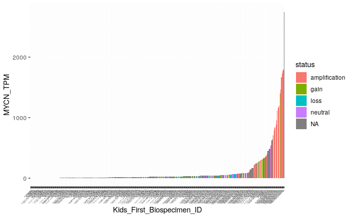

```r
plot_alteration_df <- alteration_df %>% filter(!is.na(MYCN_TPM))
plot_alteration_df<- plot_alteration_df %>% mutate(Kids_First_Biospecimen_ID=coalesce(Kids_First_Biospecimen_ID_DNA,Kids_First_Biospecimen_ID_RNA))

bar_plot2<-plot_alteration_df %>%
  arrange(MYCN_TPM) %>%
  mutate(Kids_First_Biospecimen_ID = factor(Kids_First_Biospecimen_ID, unique(Kids_First_Biospecimen_ID))) %>%
  ggplot() +aes(x=Kids_First_Biospecimen_ID, y=MYCN_TPM, fill=status)+
  geom_bar(position="dodge",stat="identity")+
  theme(axis.text.x = element_text(size = 2, angle = 45, hjust = 1))
bar_plot2
```

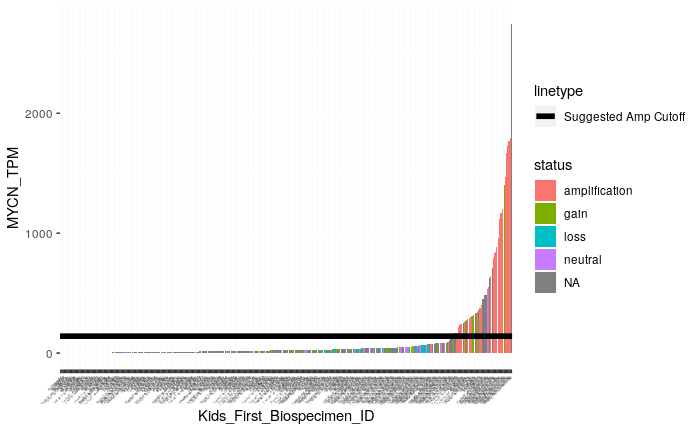

```r
Suggested_Cutoff<-140.83 # TARGET-30-PAMEZH-01A-01R
bar_plot2+ geom_hline(aes(yintercept=Suggested_Cutoff,linetype = "Suggested Amp Cutoff"),color = "black",size=2) #TARGET-30-PAPKXS-01A-01D

plot_file <- file.path(plot_dir, "TPM_Biospecimen_All_Samples_With_TMP.png")
ggsave(filename = plot_file,width = 49, height = 20)
```

Code Logic: Start the subtyping on alteration_df. Here are subtyping criteria: case 1: If pathology_free_text_diagnosis is amplification and status is amplification assign subtype as “NBL, MYCN amplified” case 2: If pathology_free_text_diagnosis is non-amp and status is amplification assign subtype as “NBL, MYCN amplified” case 3: If pathology_free_text_diagnosis is non-amp and status is non-amp assign subtype as “NBL, MYCN non-amplified”

```r
alteration_df<-alteration_df %>%mutate(subtype = case_when(status =="amplification" & pathology_free_text_diagnosis=="MYCN amp"
                                                  ~ "NBL, MYCN amplified",status =="amplification" &
                                                    pathology_free_text_diagnosis %in%
                                                    c("MYCN non-amp","ganglioneuroblastoma, stage ii favorable histology non n-myc amplified")
                                                  ~ "NBL, MYCN amplified",
                                       status %in% c("gain","loss","neutral") &
                                         pathology_free_text_diagnosis %in%
                                         c("MYCN non-amp","ganglioneuroblastoma, stage ii favorable histology non n-myc amplified")
                                       ~ "NBL, MYCN non-amplified"))
```

Code Logic: If there is mismatch between pathology_free_text_diagnosis and status  
case 4: pathology_free_text_diagnosis is amped and status is non amp First we find such cases and then plot thier segmean vs location plots.

```r
# If MYCN is called non-amplified but clinical file says amplified, plot the CNV data to visualize whether we see focal amplification but the CNV was not called.

index_clinical_amplified <- which(alteration_df$status %in% c("gain","loss","neutral")
                                  & alteration_df$pathology_free_text_diagnosis=="MYCN amp")

clincal_amplified_IDs <- alteration_df$Kids_First_Biospecimen_ID_DNA[index_clinical_amplified]


print("Biospecimens for which pathology (clinical) file says  amplified but call is loss, gain or netural")
```

```
[1] "Biospecimens for which pathology (clinical) file says  amplified but call is loss, gain or netural"
```

```r
print(clincal_amplified_IDs)
```

```
 [1] "BS_8XDZQKSD"              "BS_A5AQFAFA"              "BS_ACCE0MEA"              "BS_FJP95JXF"              "BS_QDRHQSPZ"              "TARGET-30-PAMMXF-01A-01W"
 [7] "TARGET-30-PASXIE-01A-01D" "BS_4WSW3X49"              "BS_6K2SSJ77"              "BS_E4V8XN3G"              "BS_WMM0MP1J"              "TARGET-30-PAKVUY-01A-01D"
[13] "TARGET-30-PAMCXF-01A-01W" "TARGET-30-PANUKV-01A-01W" "TARGET-30-PARETE-01A-01D" "TARGET-30-PARGZK-01A-01D" "TARGET-30-PARHDE-01A-01D" "TARGET-30-PARHUX-01A-01D"
[19] "TARGET-30-PASKFV-01A-01D"
```

Code Logic: For the case 4 create the plots.

```r
for (iter in 1: length(clincal_amplified_IDs)){
  if(!is.na(clincal_amplified_IDs[iter])){
    plot_chr2(cnv_cnvkit_df,clincal_amplified_IDs[iter])
    plt_file <- file.path(plot_dir, paste(clincal_amplified_IDs[iter],"_Amp_Del",".png",sep=""))
    ggsave(filename = plt_file,width = 10, height = 20)
  }
  else{
    plot_chr2(cnv_cnvkit_df,alteration_df$Kids_First_Biospecimen_ID_RNA[index_clinical_amplified[iter]])
    plt_file <- file.path(plot_dir, paste(clincal_amplified_IDs[iter],"_Amp_Del",".png",sep=""))
    ggsave(filename = plt_file,width = 10, height = 20)
  }

}
```

Code Logic: Case 4:pathology_free_text_diagnosis is amped and status is non amp For the samples that have a TPM value see if they are above or below the Suggested_Cutoff established in plot barplot of TPM_Biospecimen_All_Samples_With_TMP.png. If TPM values are above or equal to Suggested_Cutoff assign “NBL, MYCN amplified” otherwise, assign “NBL, MYCN non-amplified”. In case there is no TPM values then assign “Pathology-amp,Status-non-amp,TPM-NA,” we will change this to NA later.

```r
index_clincal <- NA
for (iter in index_clinical_amplified){
  if(is.na(alteration_df$MYCN_TPM[iter])){
    alteration_df$subtype[iter]<- "Pathology-amp,Status-non-amp,TPM-NA"

  }
  else if (alteration_df$MYCN_TPM[iter] >= Suggested_Cutoff){
   alteration_df$subtype[iter]<- "NBL, MYCN amplified"
   index_clincal <- c(index_clincal,iter)

 }
  else if (alteration_df$MYCN_TPM[iter] < Suggested_Cutoff) {
    alteration_df$subtype[iter]<- "NBL, MYCN non-amplified"
    index_clincal <- c(index_clincal,iter)

  }

}
```

Code Logic: Case 5: Find the samples where we don’t have subtype but there is a TPM then assign subtype based on Suggested_Cutoff.

```r
index_tpm_unsubtype_above<-which(is.na(alteration_df$subtype) & !is.na(alteration_df$MYCN_TPM)& alteration_df$MYCN_TPM >= Suggested_Cutoff)

index_tpm_unsubtype_below<-which(is.na(alteration_df$subtype) & !is.na(alteration_df$MYCN_TPM)& alteration_df$MYCN_TPM < Suggested_Cutoff)

alteration_df$subtype[index_tpm_unsubtype_above]<-"NBL, MYCN amplified"

alteration_df$subtype[index_tpm_unsubtype_below]<-"NBL, MYCN non-amplified"
```

Code Logic: For the samples which are not assigned a subtype we will assign the subtype field as “Unclassified due to insufficient info”. We will later change this to NA.

```r
index_unclassified <- which(is.na(alteration_df$subtype))
alteration_df$subtype[index_unclassified]<-"Unclassified due to insufficient info"
```

Code Logic: create a dataframe containing all the samples whose subtype was determined based on TPM.

```r
index_clincal<- index_clincal[2:length(index_clincal)] # Remove NA at index 1

TPM_index <- c(index_clincal,index_tpm_unsubtype_above,index_tpm_unsubtype_below)

df_tpm <- alteration_df[TPM_index,]

df_tpm <- df_tpm %>% select(Kids_First_Biospecimen_ID_DNA,Kids_First_Biospecimen_ID_RNA,copy_number,
                            pathology_free_text_diagnosis,status,MYCN_TPM,subtype)
```

# QC Check

```r
TARGET2<- hist_df %>% filter(cohort=="TARGET",pathology_diagnosis %in%
                               c("Neuroblastoma", "Ganglioneuroblastoma","Ganglioneuroblastoma, nodular",
                                 "Ganglioneuroblastoma, intermixed","Ganglioneuroma, maturing subtype OR Ganglioneuroblastoma, well differentiated"),
                            experimental_strategy=="WXS")

GMKF2<- hist_df %>% filter(cohort=="GMKF",pathology_diagnosis %in%
                             c("Neuroblastoma", "Ganglioneuroblastoma","Ganglioneuroblastoma, nodular",
                               "Ganglioneuroblastoma, intermixed","Ganglioneuroma, maturing subtype OR Ganglioneuroblastoma, well differentiated"),
                           experimental_strategy=="WGS")

TARGET2 <- TARGET2 %>% select(Kids_First_Biospecimen_ID,Kids_First_Participant_ID,sample_id,
                              cohort,experimental_strategy)
GMKF2 <- GMKF2 %>% select(Kids_First_Biospecimen_ID,Kids_First_Participant_ID,sample_id,
                          cohort,experimental_strategy)

QC_df <- inner_join(GMKF2,TARGET2, by= c("Kids_First_Participant_ID","sample_id"))

QC_df <-  QC_df %>% select(Kids_First_Biospecimen_ID.x,Kids_First_Biospecimen_ID.y,Kids_First_Participant_ID,sample_id,
                           cohort.x,cohort.y,experimental_strategy.x,experimental_strategy.y)

colnames(QC_df)<- c("Kids_First_Biospecimen_ID_GMKF","Kids_First_Biospecimen_ID_TARGET",
                        "Kids_First_Participant_ID","sample_id","cohort_GMKF","cohort_TARGET",
                        "experimental_strategy_GMKF","experimental_strategy_Target")

QC_df$TPM_GMKF<-NA
QC_df$TPM_Target<-NA

QC_df$status_GMKF<-NA
QC_df$status_Target<-NA

QC_df$subtype_GMKF<-NA
QC_df$subtype_Target<-NA

for (iter in 1:dim(QC_df)[1]){
  index_gmkf <- which(alteration_df$Kids_First_Biospecimen_ID_DNA == QC_df$Kids_First_Biospecimen_ID_GMKF[iter])
  index_target <- which(alteration_df$Kids_First_Biospecimen_ID_DNA == QC_df$Kids_First_Biospecimen_ID_TARGET[iter])

  if(length(index_gmkf) ==0 ){
    index_gmkf <- which(alteration_df$Kids_First_Biospecimen_ID_RNA == QC_df$Kids_First_Biospecimen_ID_GMKF[iter])
  }
  QC_df$TPM_GMKF[iter]<- alteration_df$MYCN_TPM[index_gmkf]
  QC_df$status_GMKF[iter]<- alteration_df$status[index_gmkf]
  QC_df$subtype_GMKF[iter]<- alteration_df$subtype[index_gmkf]

  if(length(index_target) ==0 ){
    index_target <- which(alteration_df$Kids_First_Biospecimen_ID_RNA ==
                            QC_df$Kids_First_Biospecimen_ID_TARGET[iter])
  }
  QC_df$TPM_Target[iter]<- alteration_df$MYCN_TPM[index_target]
  QC_df$status_Target[iter]<- alteration_df$status[index_target]
  QC_df$subtype_Target[iter]<- alteration_df$subtype[index_target]
}
```

# Write the tables.

```r
subtype_table <- alteration_df %>% select(Kids_First_Biospecimen_ID_DNA,Kids_First_Biospecimen_ID_RNA,subtype)
index_NA<-which(subtype_table$subtype %in% c("Unclassified due to insufficient info","Pathology-amp,Status-non-amp,TPM-NA"))
subtype_table$subtype[index_NA]<-NA_character_
subtype_table<-subtype_table[order(subtype_table$subtype),]
```

#Part 7: Write the table

```r
alteration_df%>%readr::write_tsv(file.path(results_dir, "Alteration_Table.tsv"))
df_tpm%>%readr::write_tsv(file.path(results_dir, "Subtypes_Based_On_Cutoff.tsv"))
QC_df%>%readr::write_tsv(file.path(results_dir, "QC_table.tsv"))
subtype_table%>%readr::write_tsv(file.path(results_dir, "NBL_MYCN_Subtype.tsv"))
```

# References

[1]https://github.com/PediatricOpenTargets/OpenPedCan-analysis/blob/dev/analyses/independent-samples/util/independent-rna-samples.R

[2]https://www.codingprof.com/3-easy-ways-to-remove-empty-columns-in-r/#:~:text=Identify%20the%20empty%20columns,empty%20values%20in%20a%20column.

[3] https://stat.ethz.ch/pipermail/r-help/2010-April/234706.html

[4]https://stackoverflow.com/questions/5234117/how-to-drop-columns-by-name-in-a-data-frame

[5]https://stackoverflow.com/questions/64638958/grouped-bars-in-descending-order